# Lab3

Okay, I think the three categories here are 1(hydrological) 2(Political/financial) 3(agricultural)

```r
k <- 4
set.seed(808)
topicModel_k4 <- LDA(dfm,
                     k,
                     method= "Gibbs",
                     control= list(iter = 1000,
                             verbose = 25))
```

```r
result <- posterior(topicModel_k4)
attributes(result)
```

```
## $names
## [1] "terms"  "topics"
```

```r
beta <- result$terms
theta <- result$topics
dim(beta)
```

```
## [1]    4 7426
```

```r
dim(theta)
```

```
## [1] 227   4
```

```r
terms(topicModel_k4, 10)
```

```
##       Topic 1      Topic 2         Topic 3   Topic 4
##  [1,] "water"      "water"         "fish"    "al"
##  [2,] "algae"      "lakes"         "salmon"  "soil"
##  [3,] "lake"       "$"             "sea"     "water"
##  [4,] "health"     "million"       "world"   "species"
##  [5,] "blue-green" "quality"       "food"    "fish"
##  [6,] "blooms"     "environmental" "prices"  "nitrogen"
##  [7,] "bloom"      "report"        "company" "plants"
##  [8,] "algal"      "amendment"     "ocean"   "study"
##  [9,] "toxins"     "program"       "plastic" "±"
## [10,] "beach"      "development"   "global"  "plant"
```

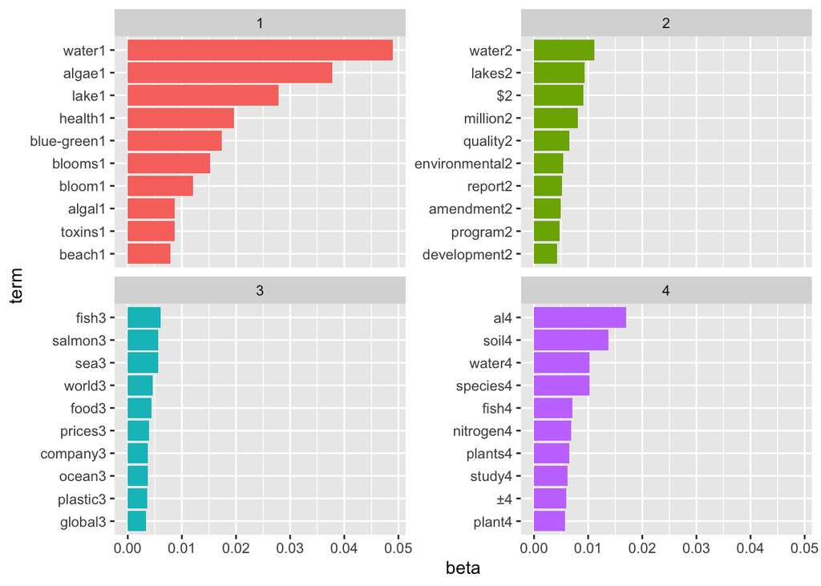

```r
topics <- tidy(topicModel_k4, matrix = "beta")

top_terms <- topics %>%
  group_by(topic) %>%
  top_n(10, beta) %>%
  ungroup() %>%
  arrange(topic, -beta)

top_terms %>%
  mutate(term = reorder_within(term, beta, topic, sep = "")) %>%
  ggplot(aes(term, beta, fill = factor(topic))) +
  geom_col(show.legend = FALSE) +
  facet_wrap(~ topic, scales = "free_y") +
  scale_x_reordered()+
  coord_flip()
```

For these categories, it seems that the categories are a little bit more specific. It seems like these might be agriculture, finance/politics, aquaculture, and algae. This seems like it might be the better choice for categories because there are categories for algae blooms and the cause of algae blooms(fertilizers/nitrogen).

```r
k <- 5
set.seed(808)
topicModel_k5 <- LDA(dfm,
                     k,
                     method= "Gibbs",
                     control= list(iter = 1000,
                             verbose = 25))
```

```r
result <- posterior(topicModel_k5)
attributes(result)
```

```
## $names
## [1] "terms"  "topics"
```

```r
beta <- result$terms
theta <- result$topics
dim(beta)
```

```
## [1]    5 7426
```

```r
dim(theta)
```

```
## [1] 227   5
```

```r
terms(topicModel_k5, 10)
```

```
##       Topic 1      Topic 2  Topic 3         Topic 4       Topic 5
##  [1,] "algae"      "fish"   "water"         "lakes"       "al"
##  [2,] "water"      "sea"    "$"             "lake"        "soil"
##  [3,] "health"     "salmon" "million"       "water"       "water"
##  [4,] "blue-green" "world"  "amendment"     "quality"     "species"
##  [5,] "lake"       "life"   "environmental" "muskoka"     "fish"
##  [6,] "bloom"      "food"   "florida"       "development" "nitrogen"
##  [7,] "blooms"     "prices" "funding"       "watershed"   "plants"
##  [8,] "toxins"     "time"   "offer"         "blooms"      "±"
##  [9,] "beach"      "ocean"  "bill"          "council"     "study"
## [10,] "algal"      "global" "federal"       "association" "plant"
```

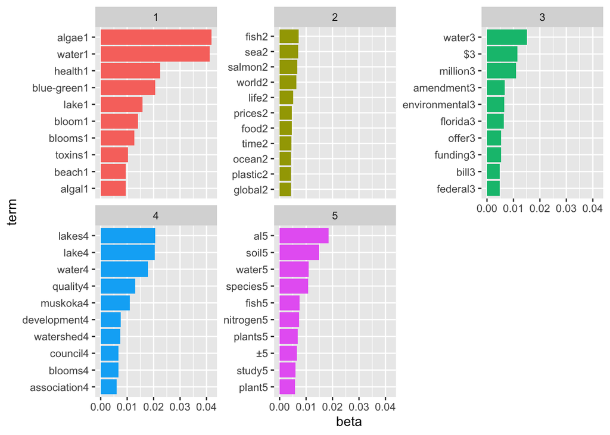

```r
topics <- tidy(topicModel_k5, matrix = "beta")

top_terms <- topics %>%
  group_by(topic) %>%
  top_n(10, beta) %>%
  ungroup() %>%
  arrange(topic, -beta)

top_terms %>%
  mutate(term = reorder_within(term, beta, topic, sep = "")) %>%
  ggplot(aes(term, beta, fill = factor(topic))) +
  geom_col(show.legend = FALSE) +
  facet_wrap(~ topic, scales = "free_y") +
  scale_x_reordered()+
  coord_flip()
```